# Chapter 13 End of Chapter Solutions

Tyler Richards

## Problem 13.1: TV Brightness

An article in Industrial Quality Control (1956, pp. 5–8) describes an experiment to investigate the effect of glass type and phosphor type on the brightness of a television tube. The response measured is the current necessary (in microamps) to obtain a specified brightness level. The data are shown in Table 13E.1. Analyze the data and draw conclusions.

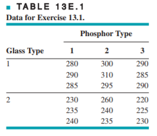

```r
#first, read in the data
Television_brightness <- read.csv("Chapter_13/Television_Brightness.csv", colClasses = c("factor", "factor", "numeric"))
```

```r
#perform anova
anova(lm(Value ~ Glass_type + Phosphor_Type + Glass_type*Phosphor_Type, data = Television_brightness))
```

```
## Analysis of Variance Table
##
## Response: Value
##                          Df  Sum Sq Mean Sq  F value    Pr(>F)
## Glass_type                1 14450.0 14450.0 273.7895 1.259e-09 ***
## Phosphor_Type             2   933.3   466.7   8.8421  0.004364 **
## Glass_type:Phosphor_Type  2   133.3    66.7   1.2632  0.317801
## Residuals                12   633.3    52.8
## ---
## Signif. codes:  0 '***' 0.001 '**' 0.01 '*' 0.05 '.' 0.1 ' ' 1
```

## Problem 13.2: Cutting Tools

A process engineer is trying to improve the life of a cutting tool. He has run a 2^3 experiment using cutting speed (A), metal hardness (B), and cutting angle (C) as the factors. The data from two replicates are shown in Table 13E.2.  
(a) Do any of the three factors affect tool life?  
(b) What combination of factor levels produces the longest tool life?  
(c) Is there a combination of cutting speed and cutting angle that always gives good results regardless of metal hardness?

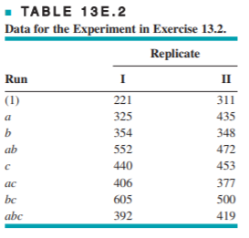

```r
#read in the data
Tool_data <- read.csv("Cutting_tool.csv", colClasses = c("factor", "factor", "factor", "factor", "numeric"))
```

```r
#use anova
Tool_model <- lm(Value ~ A + B + C + A*B + A*C + B*C + A*B*C, data = Tool_data)
Tool_model
```

```
##
## Call:
## lm(formula = Value ~ A + B + C + A * B + A * C + B * C + A *
##     B * C, data = Tool_data)
##
## Coefficients:
## (Intercept)           A1           B1           C1        A1:B1
##       266.0        114.0         85.0        180.5         47.0
##       A1:C1        B1:C1     A1:B1:C1
##      -169.0         21.0       -139.0
```

```r
anova(Tool_model)
```

```
## Analysis of Variance Table
##
## Response: Value
##           Df Sum Sq Mean Sq F value   Pr(>F)
## A          1   1332    1332  0.5410 0.483017
## B          1  28392   28392 11.5298 0.009422 **
## C          1  20592   20592  8.3623 0.020144 *
## A:B        1    506     506  0.2056 0.662297
## A:C        1  56882   56882 23.0994 0.001345 **
## B:C        1   2352    2352  0.9552 0.357017
## A:B:C      1   4830    4830  1.9615 0.198923
## Residuals  8  19700    2462
## ---
## Signif. codes:  0 '***' 0.001 '**' 0.01 '*' 0.05 '.' 0.1 ' ' 1
```

## Problem 13.3: Tool Life Probability Plot

Find the residuals from the tool life experiment in Exercise 13.2. Construct a normal probability plot of the residuals. Plot the residuals versus the predicted values. Comment on the plots.

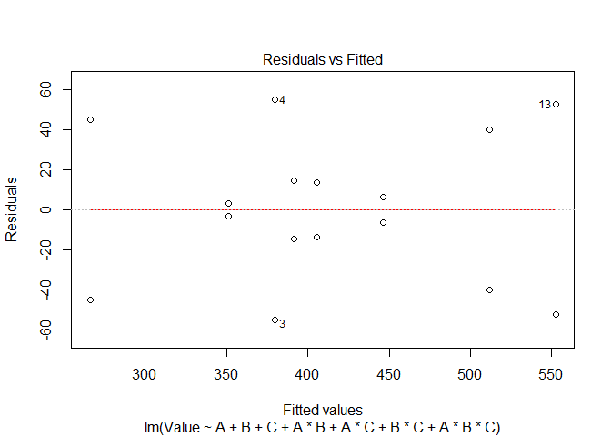

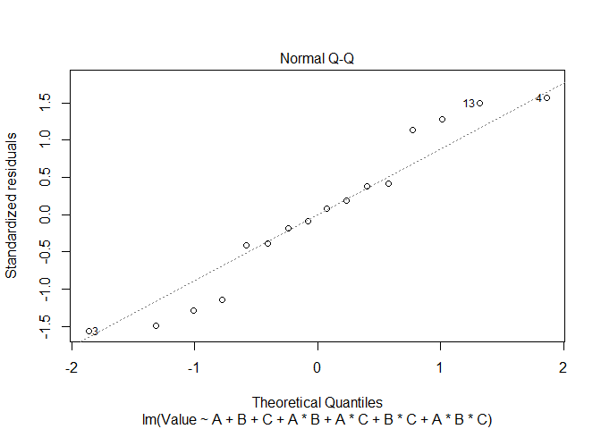

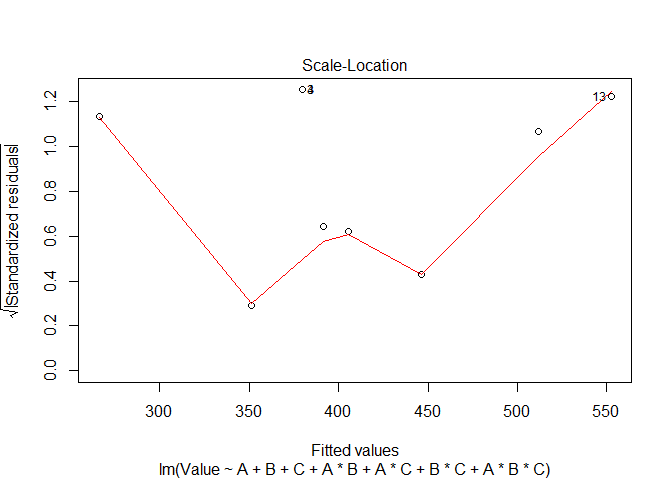

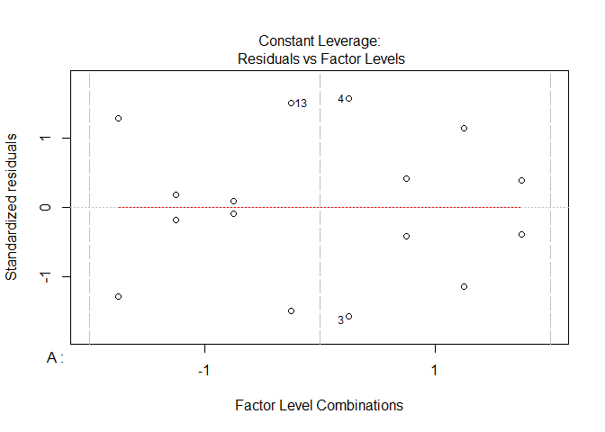

```r
#thankfully, this is super easy in R
#when you call plot(model), 4 graphs, including all the ones we need, are automatically created
#we could only request the first two graphs, but the other two are useful as well, just not in this problem.
plot(Tool_model)
```

## Problem 13.4: Soft Drink Experiment

Four factors are thought to possibly influence the taste of a soft-drink beverage: type of sweetener (A), ratio of syrup to water (B), carbonation level (C), and temperature (D). Each factor can be run at two levels, producing a 2^4 design. At each run in the design, samples of the beverage are given to a test panel consisting of 20 people. Each tester assigns a point score from 1 to 10 to the beverage. Total score is the response variable, and the objective is to find a formulation that maximizes total score. Two replicates of this design are run, and the results are shown in Table 13E.3. Analyze the data and draw conclusions.

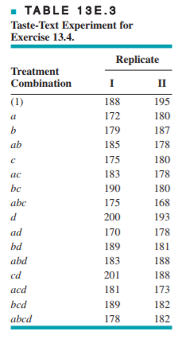

```r
Soft_drink_data <- read.csv("Soft_drink_data.csv", colClasses = c("factor", "factor", "factor", "factor", "numeric"))
```

```r
#this formula is an easier way to include all variables and all interactions terms
#the "." means "use all variables in the linear model"
#the ".*." means "use all two way interaction terms in the linear model"
#the ".*.*." means "use all three way interaction terms in the linear model"
#the ".*.*.*." means "use all four way interaction terms in the linear model"
#to be clear, you can write these out explicitly if you'd like but this is a much faster way
Soft_model <- lm(Value ~ . + .*. + .*.*. + .*.*.*., data = Soft_drink_data)

anova(Soft_model)
```

```
## Analysis of Variance Table
##
## Response: Value
##           Df Sum Sq Mean Sq F value    Pr(>F)
## A          1 930.00  930.00 31.8676 4.658e-05 ***
## B          1 125.67  125.67  4.3062   0.05559 .
## C          1   0.97    0.97  0.0333   0.85756
## D          1   7.72    7.72  0.2646   0.61447
## A:B        1 236.54  236.54  8.1052   0.01224 *
## A:C        1  19.74   19.74  0.6763   0.42374
## A:D        1   1.30    1.30  0.0445   0.83568
## B:C        1   9.36    9.36  0.3208   0.57948
## B:D        1   3.66    3.66  0.1253   0.72829
## C:D        1   9.06    9.06  0.3106   0.58555
## A:B:C      1  30.08   30.08  1.0308   0.32606
## A:B:D      1  56.25   56.25  1.9275   0.18531
## Residuals 15 437.75   29.18
## ---
## Signif. codes:  0 '***' 0.001 '**' 0.01 '*' 0.05 '.' 0.1 ' ' 1
```

## Problem 13.5: Soft Drink Probability Plots

Consider the experiment in Exercise 13.4. Plot the residuals against the levels of factors A, B, C, and D.  
Also construct a normal probability plot of the residuals. Comment on these plots.

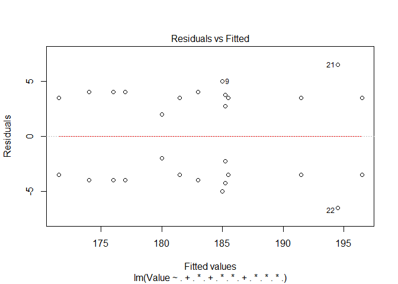

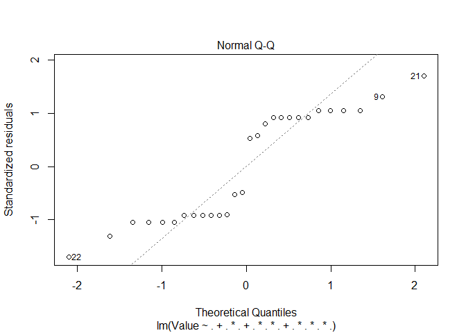

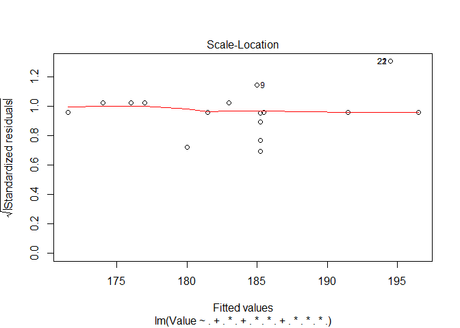

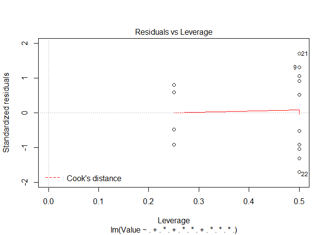

```r
plot(Soft_model)
```

```r
#these residuals are certainly not normally distributed
```